# Modeling and prediction for movies - an introdcution to data science for a movie studio

Yoshie Toriya

02/17/2021

## Introduction

I have just been hired as a data scientist at Paramount Pictures.

My boss has just acquired data about how much audiences and critics like movies, as well as numerous other variables about the movies. This dataset is provided. It includes information from Rotten Tomatoes and IMDB for a random sample of movies.

My boss is interested in learning what attributes make a movie popular. She is also interested in learning something new about movies. She wants us to figure it all out.

### Load packages and data

In this project I will explore, visualize, model and infer the data and output using below packages. So let’s load

```r
library(statsr)
library(dplyr)
library(ggplot2)
library(GGally)
library(tidyr)
```

and data

```r
load("movies.Rdata")
```

that consists of 651 observations with 32 variables:

```r
str(movies)
```

```
## Classes 'tbl_df', 'tbl' and 'data.frame':    651 obs. of  32 variables:
##  $ title           : chr  "Filly Brown" "The Dish" "Waiting for Guffman" "The Age of Innocence" ...
##  $ title_type      : Factor w/ 3 levels "Documentary",..: 2 2 2 2 2 1 2 2 1 2 ...
##  $ genre           : Factor w/ 11 levels "Action & Adventure",..: 6 6 4 6 7 5 6 6 5 6 ...
##  $ runtime         : num  80 101 84 139 90 78 142 93 88 119 ...
##  $ mpaa_rating     : Factor w/ 6 levels "G","NC-17","PG",..: 5 4 5 3 5 6 4 5 6 6 ...
##  $ studio          : Factor w/ 211 levels "20th Century Fox",..: 91 202 167 34 13 163 147 118 88 84 ...
##  $ thtr_rel_year   : num  2013 2001 1996 1993 2004 ...
##  $ thtr_rel_month  : num  4 3 8 10 9 1 1 11 9 3 ...
##  $ thtr_rel_day    : num  19 14 21 1 10 15 1 8 7 2 ...
##  $ dvd_rel_year    : num  2013 2001 2001 2001 2005 ...
##  $ dvd_rel_month   : num  7 8 8 11 4 4 2 3 1 8 ...
##  $ dvd_rel_day     : num  30 28 21 6 19 20 18 2 21 14 ...
##  $ imdb_rating     : num  5.5 7.3 7.6 7.2 5.1 7.8 7.2 5.5 7.5 6.6 ...
##  $ imdb_num_votes  : int  899 12285 22381 35096 2386 333 5016 2272 880 12496 ...
```

[output cut: 18 more lines]

A codebook of 32 variables is also available here.

### Part 1: Data collection & Generalizability/Causality

We are provided with the information that “This dataset includes information from Rotten Tomatoes and IMDB for a random sample of movies” regarding the collection of the data.  
So based on it being “a random sample”, we could say the results of the analysis could be generalizable. It might also sound otherwise by mentioning Rotten Tomatoes and IMDB, but it does NOT say the data collection was “limited” from their users but merely “included” them, so with no further information I would not deny the generalizability. Causality, however, can be denied as the data collection does not involve random assignment.

### Part 2: Research question

I believe it is well known, at least among us the data professionals, that data is extremely useful for predicting what will be a “hit” content, given [Netflix’ making House of Cards](https://www.jigsawacademy.com/how-netflix-used-data-science-to-create-one-of-the-most-loved-shows-ever-house-of-cards/) as an example. Similarly, I would like to provide my boss with the predictors for smash hit contents for company’s online streaming revenue growth within the capacity of this provided dataset. Therefore, my research question is **What is the parsimonious prediction model & what are the significant predictors the model should include**?

### Part 3: Exploratory data analysis

My EDA begins with deciding the response variable, among “Audience score” on Rotten Tomatoes (RT), “Critics score” also on RT, and “IMDB rating” on IMDB.

First, on the basics; no null value in each of those variables,

```r
sum(is.na(movies$audience_score))
```

```
## [1] 0
```

```r
sum(is.na(movies$critics_score))
```

```
## [1] 0
```

```r
sum(is.na(movies$imdb_rating))
```

```
## [1] 0
```

(There is one observation with na for “runtime”, so I’m removing this one row and will work with new dataset “movies0”.)

```r
movies0 <- movies %>%
  drop_na(runtime)
```

and the number of movie titles scored per year.

```r
mov_count <- movies0 %>%
  select(thtr_rel_year, title) %>%
  group_by(thtr_rel_year) %>%
  summarise(count = n())
```

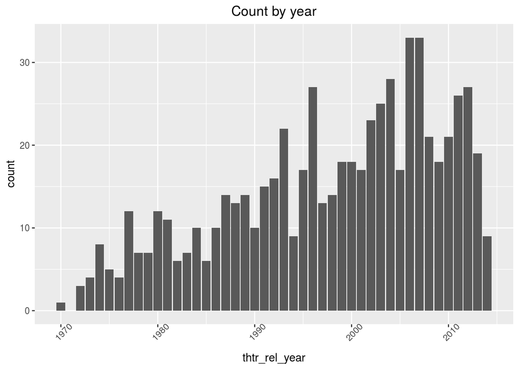

```r
ggplot(mov_count, aes(x=thtr_rel_year, y=count)) +
  geom_histogram(stat="identity") +
  theme(axis.text.x = element_text(angle = 45)) +
  ggtitle("Count by year") +
  theme(plot.title = element_text(hjust = 0.5))
```

Looking at the years, I was curious whether the gap between the year of the release and that of the score provided (in other words, how later the movie was scored after its release) might be an influential factor. But, as that is unknown, I checked whether there’s any association between the year of release and the score given (using “audience_score”):

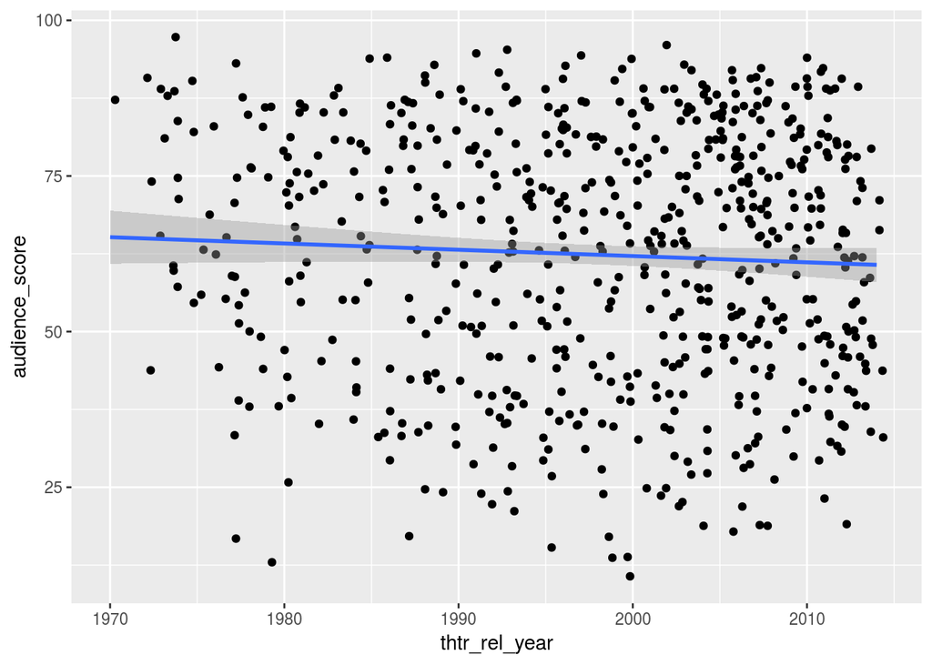

```r
ggplot(data = movies0, aes(x = thtr_rel_year, y = audience_score)) +
  geom_jitter() +
  geom_smooth(method = "lm")
```

The measurement as below, as well as the visualization above, does not support the idea of association.

```r
corr_01 = lm(audience_score ~ thtr_rel_year, data = movies0)
summary(corr_01)
```

```
##
## Call:
## lm(formula = audience_score ~ thtr_rel_year, data = movies0)
##
## Residuals:
##     Min      1Q  Median      3Q     Max
## -51.260 -15.979   3.069  17.170  34.064
##
## Coefficients:
##                Estimate Std. Error t value Pr(>|t|)
## (Intercept)   264.18118  144.47857   1.829   0.0679 .
## thtr_rel_year  -0.10102    0.07231  -1.397   0.1629
## ---
## Signif. codes:  0 '***' 0.001 '**' 0.01 '*' 0.05 '.' 0.1 ' ' 1
##
## Residual standard error: 20.22 on 648 degrees of freedom
## Multiple R-squared:  0.003003,   Adjusted R-squared:  0.001464
## F-statistic: 1.952 on 1 and 648 DF,  p-value: 0.1629
```

Next check is the association between “audience score” and “critics score”,

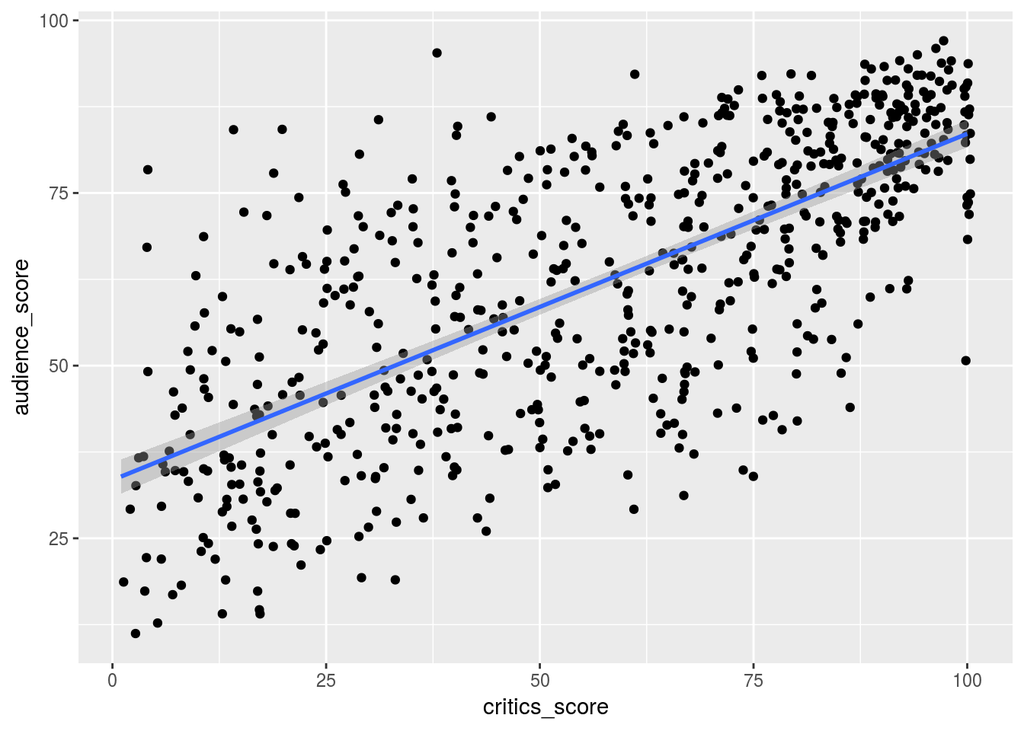

```r
ggplot(data = movies0, aes(x = critics_score, y = audience_score)) +
  geom_jitter() +
  geom_smooth(method = "lm")
```

```r
corr_02 = lm(audience_score ~ critics_score, data = movies0)
summary(corr_02)
```

```
##
## Call:
## lm(formula = audience_score ~ critics_score, data = movies0)
##
## Residuals:
##     Min      1Q  Median      3Q     Max
## -37.047  -9.580   0.711  10.418  43.545
##
## Coefficients:
##               Estimate Std. Error t value Pr(>|t|)
## (Intercept)   33.43408    1.27665   26.19   <2e-16 ***
## critics_score  0.50150    0.01987   25.25   <2e-16 ***
## ---
## Signif. codes:  0 '***' 0.001 '**' 0.01 '*' 0.05 '.' 0.1 ' ' 1
##
## Residual standard error: 14.38 on 648 degrees of freedom
## Multiple R-squared:  0.4958, Adjusted R-squared:  0.4951
## F-statistic: 637.3 on 1 and 648 DF,  p-value: < 2.2e-16
```

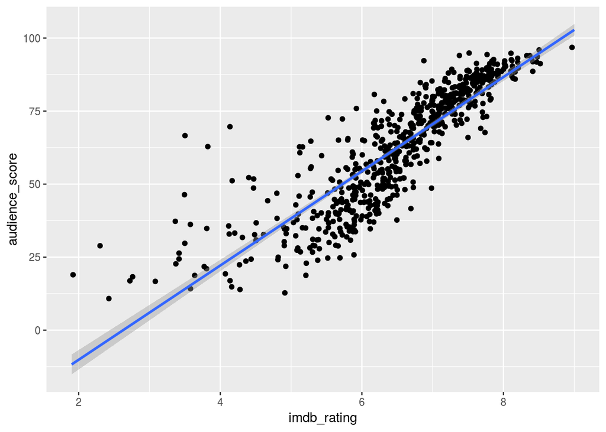

```r
ggplot(data = movies0, aes(x = imdb_rating, y = audience_score)) +
  geom_jitter() +
  geom_smooth(method = "lm")
```

```r
corr_03 = lm(audience_score ~ imdb_rating, data = movies0)
summary(corr_03)
```

```
##
## Call:
## lm(formula = audience_score ~ imdb_rating, data = movies0)
##
## Residuals:
##     Min      1Q  Median      3Q     Max
## -26.805  -6.550   0.676   5.676  52.912
##
## Coefficients:
##             Estimate Std. Error t value Pr(>|t|)
## (Intercept) -42.3748     2.4205  -17.51   <2e-16 ***
## imdb_rating  16.1321     0.3678   43.87   <2e-16 ***
## ---
## Signif. codes:  0 '***' 0.001 '**' 0.01 '*' 0.05 '.' 0.1 ' ' 1
##
## Residual standard error: 10.16 on 648 degrees of freedom
## Multiple R-squared:  0.7481, Adjusted R-squared:  0.7477
## F-statistic:  1924 on 1 and 648 DF,  p-value: < 2.2e-16
```

There is strong association. I will choose “Audience Score” to be the predicted variable. While the collinearity among them suggest choosing any of them would not make a huge difference, the audience satisfaction is the ultimate goal of the business. And “critics_score” and “imdb_rating” will not be included as explanatory variables due to their strong association.

Now onto explanatory variables.  
Knowing the key predictors from the House of Cards example, I continued exploration with the following categorical variables:

“Genre”

```r
movies0 %>%
  select(title, genre, audience_score) %>%
  group_by(genre) %>%
  summarize(count = n(), mean = mean(audience_score), median = median(audience_score), min = min(audience_score), max = max(audience_score)) %>%
  arrange(desc(count))
```

```
## # A tibble: 11 x 6
##    genre                     count  mean median   min   max
##    <fct>                     <int> <dbl>  <dbl> <dbl> <dbl>
##  1 Drama                       305  65.3   70      13    95
##  2 Comedy                       87  52.5   50      19    93
##  3 Action & Adventure           65  53.8   52      11    94
##  4 Mystery & Suspense           59  55.9   54      15    97
##  5 Documentary                  51  83.0   86      57    96
##  6 Horror                       23  45.8   43      24    84
##  7 Other                        16  66.7   73.5    21    91
##  8 Art House & International    14  64     65.5    29    86
##  9 Musical & Performing Arts    12  80.2   80.5    55    95
## 10 Animation                     9  62.4   65      18    88
## 11 Science Fiction & Fantasy     9  50.9   47      17    85
```

that shows interesting variability as below:

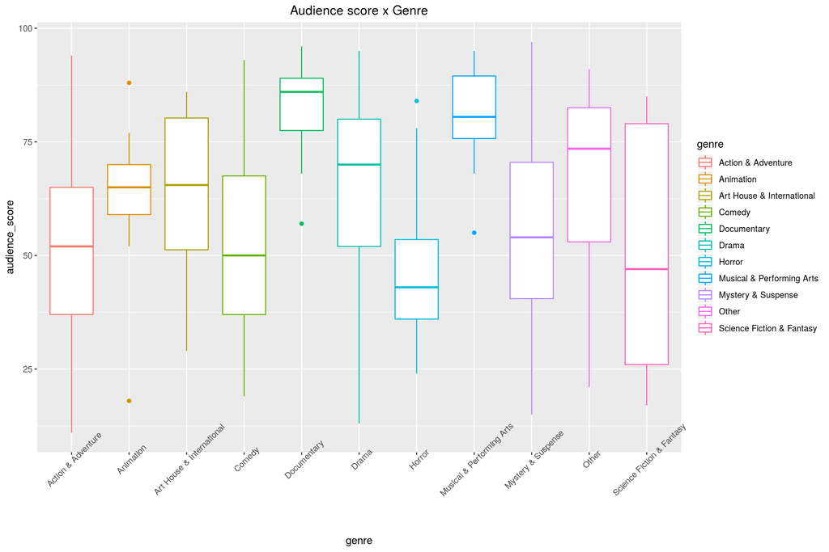

```r
ggplot(movies0, aes(x = genre, y = audience_score, color = genre)) +
    geom_boxplot()+
  theme(axis.text.x = element_text(angle = 45, size = 9)) +
  ggtitle("Audience score x Genre") +
  theme(plot.title = element_text(hjust = 0.5))
```

So does genre with “mpaa rating” (G, NC-17, PG, PG-13, R, etc.):

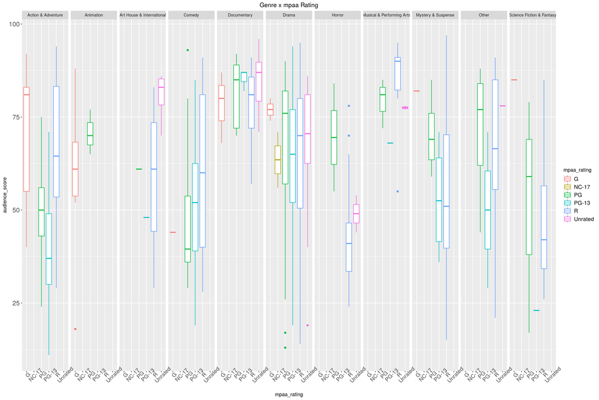

```r
ggplot(movies0, aes(x = mpaa_rating, y = audience_score, color = mpaa_rating)) +
    geom_boxplot()+
  theme(axis.text.x = element_text(angle = 45, size = 12)) +
  theme(axis.text.y = element_text(size = 14)) +
  ggtitle("Genre x mpaa Rating") +
    facet_grid(.~genre)+
  theme(plot.title = element_text(hjust = 0.5)) +
  theme(legend.text = element_text(size = 12))
```

which also shows interesting variance.  
How about “Studio”?:

```r
movies0 %>%
  select(title, audience_score, studio) %>%
  group_by(studio) %>%
  summarize(count = n(), mean = mean(audience_score), median = median(audience_score), min = min(audience_score), max = max(audience_score)) %>%
  arrange(desc(count))
```

```
## # A tibble: 211 x 6
##    studio                                   count  mean median   min   max
##    <fct>                                    <int> <dbl>  <dbl> <dbl> <dbl>
##  1 Paramount Pictures                          37  64.0   63      24    97
##  2 Warner Bros. Pictures                       30  63.3   68.5    11    90
##  3 Sony Pictures Home Entertainment            27  55     52      19    89
##  4 Universal Pictures                          23  68.5   73      29    95
##  5 Warner Home Video                           19  59.6   59      24    94
##  6 20th Century Fox                            18  54.9   55      19    87
##  7 Miramax Films                               18  62.9   63.5    30    94
##  8 MGM                                         16  46.6   40      17    84
##  9 Twentieth Century Fox Home Entertainment    14  59.8   66.5    31    87
## 10 IFC Films                                   13  60.8   66      32    84
## # … with 201 more rows
```

There are 211 studios with my employer Paramount Pictures on top of the list. I plot the data narrowing down to the top 10 studios:

```r
t10_studios <- movies0 %>%
  filter((studio == "Paramount Pictures") | (studio == "Warner Bros. Pictures") | (studio == "Sony Pictures Home Entertainment") | (studio == "Universal Pictures")| (studio == "Warner Home Video") | (studio == "20th Century Fox") | (studio == "Miramax Films") | (studio == "MGM") | (studio == "Twentieth Century Fox Home Entertainment") | (studio == "IFC Films"))
```

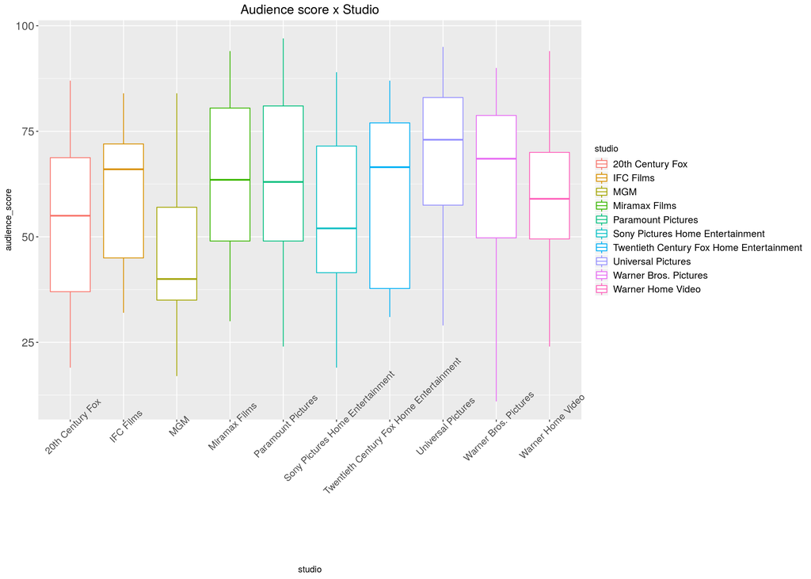

```r
ggplot(t10_studios, aes(x = studio, y = audience_score, color = studio)) +
    geom_boxplot()+
  theme(axis.text.x = element_text(angle = 45, size = 12)) +
  theme(axis.text.y = element_text(size = 14)) +
  ggtitle("Audience score x Studio") +
  theme(plot.title = element_text(hjust = 0.5, size = 16)) +
  theme(legend.text = element_text(size = 12))
```

Further, studio with genre, shows where each studio is strong or not:

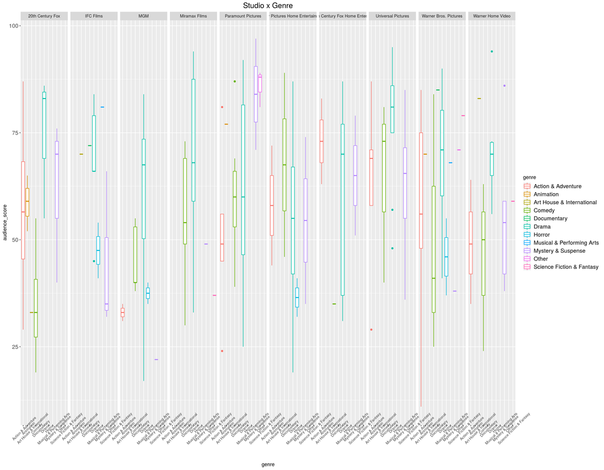

```r
ggplot(t10_studios, aes(x = genre, y = audience_score, color = genre)) +
    geom_boxplot()+
  theme(axis.text.x = element_text(angle = 45, size = 8)) +
  theme(axis.text.y = element_text(size = 12)) +
  ggtitle("Studio x Genre") +
    facet_grid(.~studio)+
  theme(plot.title = element_text(hjust = 0.5, size = 16)) +
  theme(legend.text = element_text(size = 12))
```

For further exploration on the remaining variables, I conducted single predictor regressions (the r coding of which is in the Appendix that is at the end of this page). At this point I drop other review-relate, categorical variables (because they would not add value regardless, whether they are associated or contradict with numerical scores) with 5% significance cut off.

[output not shown]

###### (Unlike what we know in House of Cards example as one of the significant predictors included was the lead actor, that is not the case with this dataset.)

Now I have the response variable, “Audience score”, and the explanatory variables for the model in order of significance indicated by the p-value;  
genre, title_type, mpaa_rating, best_pic_nom, runtime, best_pic_win, director.

### Part 4: Modeling

I am going to conduct forward selection with p-value, as my research purpose is to get a best lean model with significant predictors, by adding each explanatory variable at a time.  
Starting with “genre”:

```r
mv_01 = lm(audience_score ~ genre , data = movies0)
summary(mv_01)
```

```
##
## Call:
## lm(formula = audience_score ~ genre, data = movies0)
##
## Residuals:
##     Min      1Q  Median      3Q     Max
## -52.348 -13.348   1.215  13.652  41.051
##
## Coefficients:
##                                Estimate Std. Error t value Pr(>|t|)
## (Intercept)                      53.785      2.270  23.690  < 2e-16 ***
## genreAnimation                    8.660      6.510   1.330   0.1839
## genreArt House & International   10.215      5.393   1.894   0.0587 .
## genreComedy                      -1.279      3.001  -0.426   0.6701
## genreDocumentary                 29.176      3.424   8.521  < 2e-16 ***
## genreDrama                       11.563      2.501   4.624 4.56e-06 ***
## genreHorror                      -7.959      4.441  -1.792   0.0736 .
## genreMusical & Performing Arts   26.382      5.751   4.587 5.40e-06 ***
## genreMystery & Suspense           2.165      3.291   0.658   0.5110
## genreOther                       12.903      5.108   2.526   0.0118 *
## genreScience Fiction & Fantasy   -2.896      6.510  -0.445   0.6566
## ---
## Signif. codes:  0 '***' 0.001 '**' 0.01 '*' 0.05 '.' 0.1 ' ' 1
##
## Residual standard error: 18.3 on 639 degrees of freedom
## Multiple R-squared:  0.1943, Adjusted R-squared:  0.1817
## F-statistic: 15.41 on 10 and 639 DF,  p-value: < 2.2e-16
```

Genre yields a very small p-value.  
Now let’s add “title_type”:

```r
mv_02 = lm(audience_score ~ genre + title_type , data = movies0)
summary(mv_02)
```

```
##
## Call:
## lm(formula = audience_score ~ genre + title_type, data = movies0)
##
## Residuals:
##     Min      1Q  Median      3Q     Max
## -52.466 -13.377   1.395  13.534  41.051
##
## Coefficients:
##                                Estimate Std. Error t value Pr(>|t|)
## (Intercept)                      67.111      7.065   9.499  < 2e-16 ***
## genreAnimation                    8.660      6.494   1.333 0.182847
## genreArt House & International   10.215      5.380   1.899 0.058042 .
## genreComedy                      -1.585      2.998  -0.529 0.597096
## genreDocumentary                 16.634      7.165   2.321 0.020575 *
## genreDrama                       11.681      2.497   4.678 3.53e-06 ***
## genreHorror                      -7.959      4.430  -1.797 0.072886 .
## genreMusical & Performing Arts   21.940      6.155   3.564 0.000392 ***
## genreMystery & Suspense           2.165      3.283   0.659 0.509968
## genreOther                       13.467      5.122   2.629 0.008763 **
## genreScience Fiction & Fantasy   -2.896      6.494  -0.446 0.655820
## title_typeFeature Film          -13.326      6.692  -1.991 0.046873 *
## title_typeTV Movie              -22.349     10.632  -2.102 0.035934 *
## ---
## Signif. codes:  0 '***' 0.001 '**' 0.01 '*' 0.05 '.' 0.1 ' ' 1
##
## Residual standard error: 18.26 on 637 degrees of freedom
## Multiple R-squared:  0.2008, Adjusted R-squared:  0.1857
## F-statistic: 13.34 on 12 and 637 DF,  p-value: < 2.2e-16
```

Title_type also yields p-values below 0.05.  
Now, with “mapp_rating”:

```r
mv_03 = lm(audience_score ~ genre + title_type + mpaa_rating, data = movies0)
summary(mv_03)
```

```
##
## Call:
## lm(formula = audience_score ~ genre + title_type + mpaa_rating,
##     data = movies0)
##
## Residuals:
##    Min     1Q Median     3Q    Max
## -53.34 -13.55   1.63  13.36  40.36
##
## Coefficients:
##                                Estimate Std. Error t value Pr(>|t|)
## (Intercept)                     73.6793     8.2773   8.901  < 2e-16 ***
## genreAnimation                   2.7950     7.0745   0.395 0.692915
## genreArt House & International   8.6795     5.4792   1.584 0.113675
## genreComedy                     -0.5768     3.0061  -0.192 0.847896
## genreDocumentary                15.1059     7.2171   2.093 0.036741 *
## genreDrama                      11.9336     2.5443   4.690 3.34e-06 ***
## genreHorror                     -8.9985     4.5022  -1.999 0.046071 *
## genreMusical & Performing Arts  21.6118     6.1500   3.514 0.000473 ***
## genreMystery & Suspense          2.1760     3.3430   0.651 0.515335
## genreOther                      13.3092     5.1163   2.601 0.009504 **
## genreScience Fiction & Fantasy  -3.8876     6.4667  -0.601 0.547945
## title_typeFeature Film         -11.4109     6.7306  -1.695 0.090499 .
## title_typeTV Movie             -22.9710    10.5891  -2.169 0.030432 *
## mpaa_ratingNC-17               -10.7021    13.7516  -0.778 0.436719
## mpaa_ratingPG                   -7.8571     4.9724  -1.580 0.114573
## mpaa_ratingPG-13               -12.6294     5.0532  -2.499 0.012698 *
## mpaa_ratingR                    -7.8069     4.9217  -1.586 0.113190
## mpaa_ratingUnrated              -3.5824     5.6693  -0.632 0.527680
## ---
## Signif. codes:  0 '***' 0.001 '**' 0.01 '*' 0.05 '.' 0.1 ' ' 1
##
## Residual standard error: 18.16 on 632 degrees of freedom
## Multiple R-squared:  0.2156, Adjusted R-squared:  0.1945
## F-statistic: 10.22 on 17 and 632 DF,  p-value: < 2.2e-16
```

One level of mpaa_rating yields p-value below 0.05.  
Next, with “best_pic_nom”:

```r
mv_04 = lm(audience_score ~ genre + title_type + mpaa_rating + best_pic_nom, data = movies0)
summary(mv_04)
```

```
##
## Call:
## lm(formula = audience_score ~ genre + title_type + mpaa_rating +
##     best_pic_nom, data = movies0)
##
## Residuals:
##     Min      1Q  Median      3Q     Max
## -51.799 -13.208   1.036  13.191  39.337
##
## Coefficients:
##                                Estimate Std. Error t value Pr(>|t|)
## (Intercept)                     73.9208     8.0641   9.167  < 2e-16 ***
## genreAnimation                   2.6406     6.8923   0.383 0.701752
## genreArt House & International   8.4367     5.3381   1.580 0.114505
## genreComedy                     -0.8236     2.9290  -0.281 0.778649
## genreDocumentary                14.8428     7.0313   2.111 0.035168 *
## genreDrama                      10.5450     2.4899   4.235 2.62e-05 ***
## genreHorror                     -9.1970     4.3863  -2.097 0.036413 *
## genreMusical & Performing Arts  21.4990     5.9915   3.588 0.000359 ***
## genreMystery & Suspense          1.2783     3.2604   0.392 0.695149
## genreOther                      10.3291     5.0100   2.062 0.039646 *
## genreScience Fiction & Fantasy  -3.9416     6.3001  -0.626 0.531774
## title_typeFeature Film         -11.3420     6.5572  -1.730 0.084174 .
## title_typeTV Movie             -21.5263    10.3191  -2.086 0.037375 *
## mpaa_ratingNC-17                -9.6239    13.3985  -0.718 0.472850
## mpaa_ratingPG                   -8.3252     4.8449  -1.718 0.086223 .
## mpaa_ratingPG-13               -13.0973     4.9237  -2.660 0.008011 **
## mpaa_ratingR                    -7.9156     4.7949  -1.651 0.099268 .
## mpaa_ratingUnrated              -3.3676     5.5233  -0.610 0.542277
## best_pic_nomyes                 22.9950     3.8938   5.905 5.75e-09 ***
## ---
## Signif. codes:  0 '***' 0.001 '**' 0.01 '*' 0.05 '.' 0.1 ' ' 1
##
## Residual standard error: 17.69 on 631 degrees of freedom
## Multiple R-squared:  0.2566, Adjusted R-squared:  0.2354
## F-statistic:  12.1 on 18 and 631 DF,  p-value: < 2.2e-16
```

“Best pic nom(inated)” yields a significantly small p-value here.  
Moving on with “runtime”:

```r
mv_05 = lm(audience_score ~ genre + title_type + mpaa_rating + best_pic_nom + runtime, data = movies0)
summary(mv_05)
```

```
##
## Call:
## lm(formula = audience_score ~ genre + title_type + mpaa_rating +
##     best_pic_nom + runtime, data = movies0)
##
## Residuals:
##     Min      1Q  Median      3Q     Max
## -51.940 -12.831   1.047  12.616  38.801
##
## Coefficients:
##                                 Estimate Std. Error t value Pr(>|t|)
## (Intercept)                     60.82454    8.77735   6.930 1.04e-11 ***
## genreAnimation                   3.91124    6.83693   0.572 0.567475
## genreArt House & International   8.93929    5.29007   1.690 0.091556 .
## genreComedy                      0.36971    2.92044   0.127 0.899301
## genreDocumentary                16.13026    6.97469   2.313 0.021061 *
## genreDrama                       9.86635    2.47376   3.988 7.43e-05 ***
## genreHorror                     -7.47383    4.37157  -1.710 0.087824 .
## genreMusical & Performing Arts  20.17920    5.94678   3.393 0.000734 ***
## genreMystery & Suspense          0.58306    3.23566   0.180 0.857054
## genreOther                       9.68009    4.96639   1.949 0.051724 .
## genreScience Fiction & Fantasy  -3.70046    6.24150  -0.593 0.553475
## title_typeFeature Film         -11.48297    6.49600  -1.768 0.077595 .
## title_typeTV Movie             -20.38764   10.22752  -1.993 0.046647 *
## mpaa_ratingNC-17                -9.92200   13.27348  -0.748 0.455038
## mpaa_ratingPG                   -9.61863    4.81300  -1.998 0.046095 *
## mpaa_ratingPG-13               -15.31080    4.91618  -3.114 0.001927 **
## mpaa_ratingR                    -9.45234    4.76917  -1.982 0.047917 *
## mpaa_ratingUnrated              -5.66131    5.50860  -1.028 0.304475
## best_pic_nomyes                 19.50843    3.97704   4.905 1.19e-06 ***
## runtime                          0.14214    0.03947   3.601 0.000341 ***
## ---
## Signif. codes:  0 '***' 0.001 '**' 0.01 '*' 0.05 '.' 0.1 ' ' 1
##
## Residual standard error: 17.53 on 630 degrees of freedom
## Multiple R-squared:  0.2716, Adjusted R-squared:  0.2497
## F-statistic: 12.37 on 19 and 630 DF,  p-value: < 2.2e-16
```

Runtime also yields a very small p-value.  
Now with “best_pic_win”:

```r
mv_06 = lm(audience_score ~ genre + title_type + mpaa_rating + best_pic_nom + runtime + best_pic_win, data = movies0)
summary(mv_06)
```

```
##
## Call:
## lm(formula = audience_score ~ genre + title_type + mpaa_rating +
##     best_pic_nom + runtime + best_pic_win, data = movies0)
##
## Residuals:
##    Min     1Q Median     3Q    Max
## -51.93 -12.83   1.05  12.63  38.81
##
## Coefficients:
##                                 Estimate Std. Error t value Pr(>|t|)
## (Intercept)                     60.92641    8.79333   6.929 1.05e-11 ***
## genreAnimation                   3.90497    6.84207   0.571 0.568387
## genreArt House & International   8.93718    5.29401   1.688 0.091875 .
## genreComedy                      0.34299    2.92457   0.117 0.906677
## genreDocumentary                16.11731    6.98008   2.309 0.021264 *
## genreDrama                       9.86878    2.47562   3.986 7.50e-05 ***
## genreHorror                     -7.48358    4.37500  -1.711 0.087660 .
## genreMusical & Performing Arts  20.18940    5.95135   3.392 0.000736 ***
## genreMystery & Suspense          0.57318    3.23831   0.177 0.859566
## genreOther                       9.75435    4.97895   1.959 0.050541 .
## genreScience Fiction & Fantasy  -3.69969    6.24615  -0.592 0.553852
## title_typeFeature Film         -11.48817    6.50087  -1.767 0.077684 .
## title_typeTV Movie             -20.41181   10.23560  -1.994 0.046562 *
## mpaa_ratingNC-17                -9.91785   13.28338  -0.747 0.455562
## mpaa_ratingPG                   -9.61965    4.81659  -1.997 0.046235 *
## mpaa_ratingPG-13               -15.28051    4.92133  -3.105 0.001989 **
## mpaa_ratingR                    -9.44375    4.77285  -1.979 0.048292 *
## mpaa_ratingUnrated              -5.64769    5.51297  -1.024 0.306023
## best_pic_nomyes                 19.00958    4.45210   4.270 2.26e-05 ***
## runtime                          0.14111    0.03971   3.553 0.000409 ***
## best_pic_winyes                  1.91112    7.64364   0.250 0.802648
## ---
## Signif. codes:  0 '***' 0.001 '**' 0.01 '*' 0.05 '.' 0.1 ' ' 1
##
## Residual standard error: 17.54 on 629 degrees of freedom
## Multiple R-squared:  0.2717, Adjusted R-squared:  0.2486
## F-statistic: 11.73 on 20 and 629 DF,  p-value: < 2.2e-16
```

“Best picture win(:yes)” yields a very large p-value, so let’s remove it and add the last variable  
“director”:

```r
mv_06_2 = lm(audience_score ~ genre + title_type + mpaa_rating + best_pic_nom + runtime + director, data = movies0)
options(max.print=120) #Avoid printing too many director levels
print(summary(mv_06_2), concise=TRUE)
```

```
##
## Call:
## lm(formula = audience_score ~ genre + title_type + mpaa_rating +
##     best_pic_nom + runtime + director, data = movies0)
##
## Residuals:
##    Min     1Q Median     3Q    Max
## -35.88   0.00   0.00   0.00  33.26
##
## Coefficients: (2 not defined because of singularities)
##                                       Estimate Std. Error t value Pr(>|t|)
## (Intercept)                           78.66289   27.70453   2.839 0.005476
## genreAnimation                        -7.63463   15.87456  -0.481 0.631613
## genreArt House & International        -2.80790   13.47315  -0.208 0.835335
## genreComedy                            5.15201    7.66958   0.672 0.503295
## genreDocumentary                     -33.09037   29.54045  -1.120 0.265324
## genreDrama                            11.05338    6.10300   1.811 0.073122
## genreHorror                            3.78459   13.79050   0.274 0.784317
## genreMusical & Performing Arts        13.66875   13.68641   0.999 0.320346
## genreMystery & Suspense                9.41617    7.77092   1.212 0.228476
## genreOther                             0.52026   11.36460   0.046 0.963578
## genreScience Fiction & Fantasy        -1.27637   17.11934  -0.075 0.940716
## title_typeFeature Film               -44.27016   23.96662  -1.847 0.067681
## title_typeTV Movie                  -109.84992   34.06059  -3.225 0.001702
## mpaa_ratingNC-17                      22.62804   24.15940   0.937 0.351213
## mpaa_ratingPG                        -14.96252   13.95479  -1.072 0.286205
## mpaa_ratingPG-13                     -21.01566   14.24837  -1.475 0.143367
## mpaa_ratingR                         -11.02026   14.15897  -0.778 0.438216
## mpaa_ratingUnrated                     6.22502   21.65025   0.288 0.774304
## best_pic_nomyes                       27.13857    7.80189   3.478 0.000748
## runtime                                0.03525    0.10906   0.323 0.747190
## directorAbel Ferrara                  30.08429   19.71477   1.526 0.130172
## directorAdam McKay                    29.27603   19.83429   1.476 0.143078
## directorAdam Salky                    -3.66895   19.68637  -0.186 0.852532
## directorAdam Shankman                 47.77665   24.26125   1.969 0.051691
##
## (Intercept)                         **
## genreAnimation
## genreArt House & International
## genreComedy
```

[output cut: 13 more lines]

```
## mpaa_ratingUnrated
## best_pic_nomyes                     ***
## runtime
## directorAbel Ferrara
## directorAdam McKay
## directorAdam Salky
## directorAdam Shankman               .
##  [ reached getOption("max.print") -- omitted 526 rows ]
## ---
## Signif. codes:  0 '***' 0.001 '**' 0.01 '*' 0.05 '.' 0.1 ' ' 1
##
## Residual standard error: 15.67 on 100 degrees of freedom
##   (2 observations deleted due to missingness)
## Multiple R-squared:  0.9075, Adjusted R-squared:  0.4018
## F-statistic: 1.794 on 547 and 100 DF,  p-value: 0.0002228
```

Adding director has changed the p-values of “genre” and “mpaa_rating” to much larger figures, and specifically especially “runtime” to nearly 0.75. As they were indicated being more significant through the single predictor regression earlier, I would like to drop “director”, but want to see what happens by removing “runtime”.

```r
mv_05_2 = lm(audience_score ~ genre + title_type + mpaa_rating + best_pic_nom + director, data = movies0)
options(max.print=120) #Avoid printing too many director levels
print(summary(mv_05_2), concise=TRUE)
```

```
##
## Call:
## lm(formula = audience_score ~ genre + title_type + mpaa_rating +
##     best_pic_nom + director, data = movies0)
##
## Residuals:
##    Min     1Q Median     3Q    Max
## -36.07   0.00   0.00   0.00  33.25
##
## Coefficients: (2 not defined because of singularities)
##                                      Estimate Std. Error t value Pr(>|t|)
## (Intercept)                           82.6136    24.7523   3.338 0.001184
## genreAnimation                        -7.4940    15.7981  -0.474 0.636265
## genreArt House & International        -3.1076    13.3815  -0.232 0.816828
## genreComedy                            5.3581     7.6091   0.704 0.482950
## genreDocumentary                     -33.4197    29.3917  -1.137 0.258210
## genreDrama                            11.3447     6.0093   1.888 0.061913
## genreHorror                            3.4378    13.6876   0.251 0.802202
## genreMusical & Performing Arts        13.2737    13.5712   0.978 0.330372
## genreMystery & Suspense                9.8330     7.6291   1.289 0.200385
## genreOther                             0.7060    11.2996   0.062 0.950301
## genreScience Fiction & Fantasy        -0.4111    16.8336  -0.024 0.980563
## title_typeFeature Film               -45.5276    23.5437  -1.934 0.055944
## title_typeTV Movie                  -110.8755    33.7618  -3.284 0.001407
## mpaa_ratingNC-17                      22.5692    24.0514   0.938 0.350290
## mpaa_ratingPG                        -14.8873    13.8909  -1.072 0.286394
## mpaa_ratingPG-13                     -20.6548    14.1414  -1.461 0.147233
## mpaa_ratingR                         -10.8754    14.0890  -0.772 0.441973
## mpaa_ratingUnrated                     7.4527    21.2198   0.351 0.726158
## best_pic_nomyes                       28.0886     7.1950   3.904 0.000171
## directorAbel Ferrara                  30.4446    19.5958   1.554 0.123400
## directorAdam McKay                    30.2107    19.5352   1.546 0.125118
## directorAdam Salky                    -3.5554    19.5958  -0.181 0.856388
## directorAdam Shankman                 49.5276    23.5437   2.104 0.037894
## directorAdam Simon                    -5.6484    23.1908  -0.244 0.808063
##
## (Intercept)                         **
## genreAnimation
## genreArt House & International
## genreComedy
```

[output cut: 13 more lines]

```
## mpaa_ratingUnrated
## best_pic_nomyes                     ***
## directorAbel Ferrara
## directorAdam McKay
## directorAdam Salky
## directorAdam Shankman               *
## directorAdam Simon
##  [ reached getOption("max.print") -- omitted 525 rows ]
## ---
## Signif. codes:  0 '***' 0.001 '**' 0.01 '*' 0.05 '.' 0.1 ' ' 1
##
## Residual standard error: 15.6 on 101 degrees of freedom
##   (2 observations deleted due to missingness)
## Multiple R-squared:  0.9074, Adjusted R-squared:  0.4071
## F-statistic: 1.814 on 546 and 101 DF,  p-value: 0.000167
```

```r
mv_05 = lm(audience_score ~ genre + title_type + mpaa_rating + best_pic_nom + runtime, data = movies0)
summary(mv_05)
```

```
##
## Call:
## lm(formula = audience_score ~ genre + title_type + mpaa_rating +
##     best_pic_nom + runtime, data = movies0)
##
## Residuals:
##     Min      1Q  Median      3Q     Max
## -51.940 -12.831   1.047  12.616  38.801
##
## Coefficients:
##                                 Estimate Std. Error t value Pr(>|t|)
## (Intercept)                     60.82454    8.77735   6.930 1.04e-11 ***
## genreAnimation                   3.91124    6.83693   0.572 0.567475
## genreArt House & International   8.93929    5.29007   1.690 0.091556 .
## genreComedy                      0.36971    2.92044   0.127 0.899301
## genreDocumentary                16.13026    6.97469   2.313 0.021061 *
## genreDrama                       9.86635    2.47376   3.988 7.43e-05 ***
## genreHorror                     -7.47383    4.37157  -1.710 0.087824 .
## genreMusical & Performing Arts  20.17920    5.94678   3.393 0.000734 ***
## genreMystery & Suspense          0.58306    3.23566   0.180 0.857054
## genreOther                       9.68009    4.96639   1.949 0.051724 .
## genreScience Fiction & Fantasy  -3.70046    6.24150  -0.593 0.553475
## title_typeFeature Film         -11.48297    6.49600  -1.768 0.077595 .
## title_typeTV Movie             -20.38764   10.22752  -1.993 0.046647 *
## mpaa_ratingNC-17                -9.92200   13.27348  -0.748 0.455038
## mpaa_ratingPG                   -9.61863    4.81300  -1.998 0.046095 *
## mpaa_ratingPG-13               -15.31080    4.91618  -3.114 0.001927 **
## mpaa_ratingR                    -9.45234    4.76917  -1.982 0.047917 *
## mpaa_ratingUnrated              -5.66131    5.50860  -1.028 0.304475
## best_pic_nomyes                 19.50843    3.97704   4.905 1.19e-06 ***
## runtime                          0.14214    0.03947   3.601 0.000341 ***
## ---
## Signif. codes:  0 '***' 0.001 '**' 0.01 '*' 0.05 '.' 0.1 ' ' 1
##
## Residual standard error: 17.53 on 630 degrees of freedom
## Multiple R-squared:  0.2716, Adjusted R-squared:  0.2497
## F-statistic: 12.37 on 19 and 630 DF,  p-value: < 2.2e-16
```

This is the final model. (Note also this model yields far larger F-statistic, that is interpreted that at least one of these five variables is significant.)

As for an exercise purpose and to be sure of the selected model, I have also conduct the backward elimination with Adjusted R-squared.  
The results of Adjusted R-squared are as below (with r coding in the Appendix):

| explanatory variables | Adjusted R-squared |
| --- | --- |
| title_type + genre + runtime + mpaa_rating + best_pic_nom + best_pic_win + director | 0.3977 |
| title_type + genre + runtime + mpaa_rating + best_pic_nom + best_pic_win | 0.2486 |
| title_type + genre + runtime + mpaa_rating + best_pic_nom + director | 0.4018 |
| title_type + genre + runtime + mpaa_rating + best_pic_nom | 0.2497 |
| title_type + genre + runtime + mpaa_rating + director | 0.336 |
| title_type + genre + runtime + director | 0.3112 |
| title_type + genre + mpaa_rating + director | 0.3235 |
| title_type + genre + director | 0.3045 |
| title_type + mpaa_rating + director | 0.3251 |
| mpaa_rating + director | 0.2837 |
| genre + mpaa_rating + director | 0.2829 |

Interestingly, if I had done this fitting with Adjusted R-squared only, I might choose the third model (with director) with the highest Adjusted R-squared. But since I do know the significance of each variable through the previous fitting with p-value, I am certain the final model I have chosen is a good model.

FYI: I also have the same list with F-statistic as follows:

| explanatory variables | Adjusted R-squared | F-statistics |
| --- | --- | --- |
| title_type + genre + runtime + mpaa_rating + best_pic_nom + best_pic_win + director | 0.3977 | 1.78 |
| title_type + genre + runtime + mpaa_rating + best_pic_nom + best_pic_win | 0.2486 | 11.73 |
| title_type + genre + runtime + mpaa_rating + best_pic_nom + director | 0.4018 | 1.794 |
| title_type + genre + runtime + mpaa_rating + best_pic_nom | 0.2497 | 12.37 |
| title_type + genre + runtime + mpaa_rating + director | 0.336 | 1.6 |
| title_type + genre + runtime + director | 0.3112 | 1.539 |
| title_type + genre + mpaa_rating + director | 0.3235 | 1.567 |
| title_type + genre + director | 0.3045 | 1.523 |
| title_type + mpaa_rating + director | 0.3251 | 1.581 |
| mpaa_rating + director | 0.2837 | 1.48 |
| genre + mpaa_rating + director | 0.2829 | 1.469 |

While high F-statistic value does not assure the model is good, it indicates that at least one of the five predictors is significant. With this I stick with my selection of the model.

Now for Diagnosis - verifying whether the four conditions are met:

First for the linear relationship between x, which is runtime, the only numerical vaariable in the model, and y:

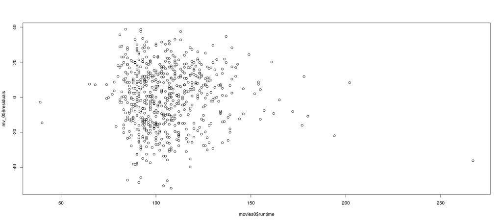

```r
mv_05 = lm(audience_score ~ genre + title_type + mpaa_rating + best_pic_nom + runtime, data = movies0)
plot(mv_05$residuals ~ movies0$runtime)
```

It looks the residuals are randomly scattered around 0, meeting the condition.

Next, for nearly normal residuals with mean 0:

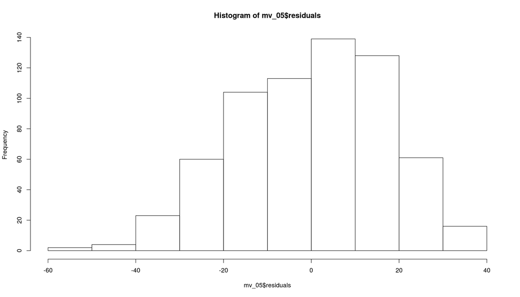

```r
hist(mv_05$residuals)
```

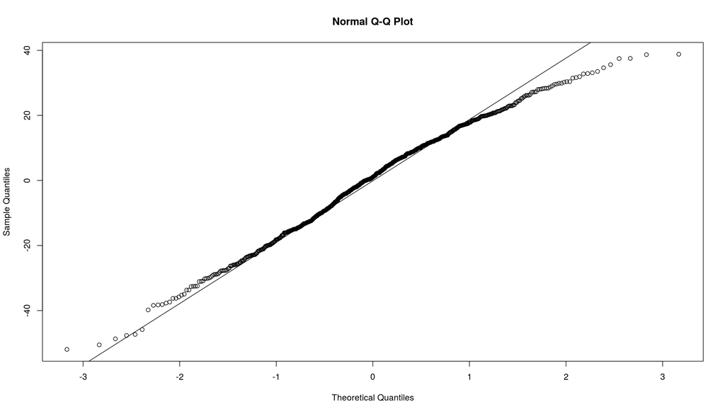

```r
qqnorm(mv_05$residuals)
qqline(mv_05$residuals)
```

while the histogram looks a little skewed, we don’t see it as a huge deviation in the probability plot, so this condition is also fairly satisfied.

Next for constant variability of residuals:

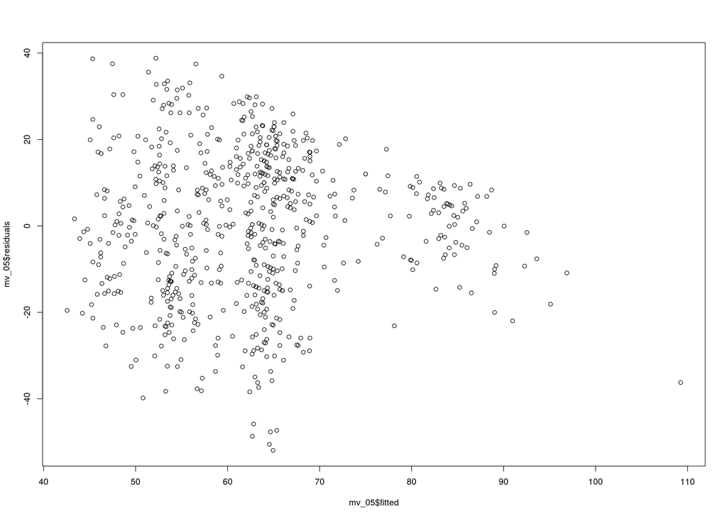

```r
plot(mv_05$residuals ~ mv_05$fitted)
```

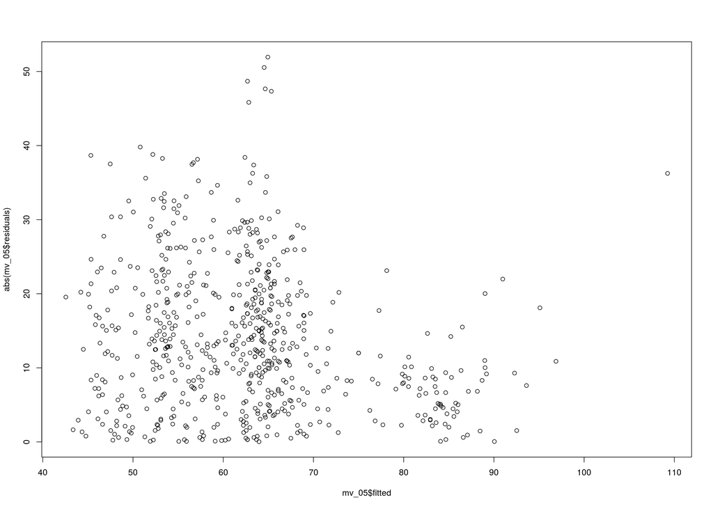

```r
plot(abs(mv_05$residuals) ~ mv_05$fitted)
```

It appears that the variability of the residual stays constant as the value of the predicted values change, not appearing fan-shaped in the residuals vs predicted plot nor triangle-shaped in the absolute residuals vs predicted plot, so the constant variability condition appears to be met.

And lastly,

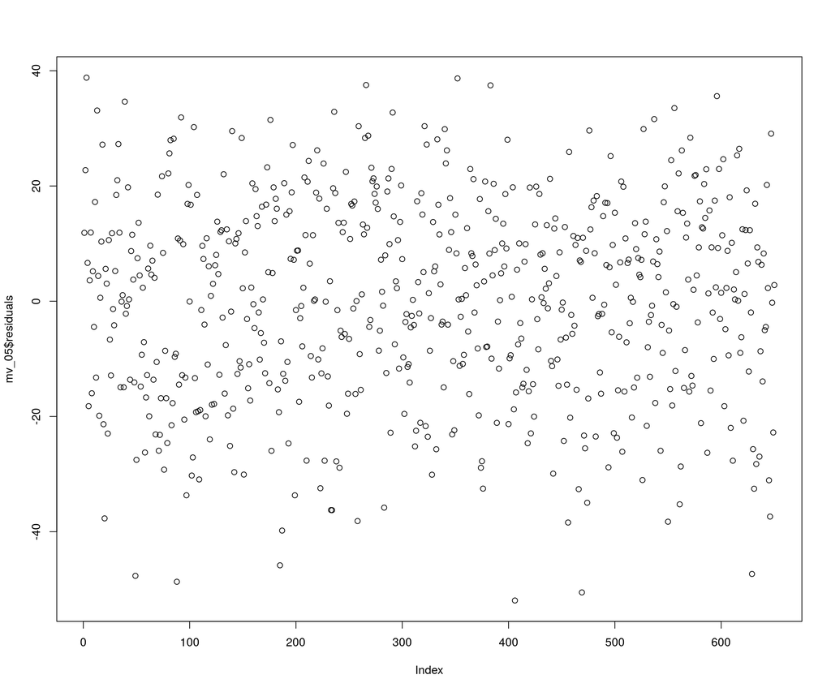

```r
plot(mv_05$residuals)
```

Again, it does not show any sign of non-independent structure between x and y, so this condition appears to be met.

##### Interpreting model coefficients

Here are the coefficients of the model:

[output not shown]

Intercept of 60.82454 is the bottomline score a movie would get if all the values of categorical variables are of the reference level and runtime is 0. But it is nonsense to think that any movie would have 0 running time, so per additional 1 minute of runtime, y is expected to increase by 0.14214 if all else is held constant.

The remaining slopes can be interpreted as the following: we would expect y to be additionally higher by the figure of the respective slope if it is a positive number, or lower if it is a negative number. The slope does not apply (as 0 to be multiplied) if the value is a reference level.

### Part 5: Prediction

Now I want to assess the model by predicting the score, so have picked [Hidden Figures](https://www.imdb.com/title/tt4846340/?ref_=fn_al_tt_1) among the 2016 movies as if for my boss’ decision making on how much to promote it based on the prediction of how well received it will be. I made a dataframe with its data that is available at [IMDB](https://www.imdb.com/title/tt4846340/?ref_=fn_al_tt_1).

```r
hidden_figures <- data.frame(
  title = c ("Hidden Figures"),
  title_type = c ("Feature Film"),
  genre = c ("Drama"),
  mpaa_rating = c ("PG"),
  runtime = c (127),
  best_pic_nom = c ("yes"),
  best_pic_win = c ("no"),
  director = c ("Theodore Melfi")
)
print(hidden_figures)
```

```
##            title   title_type genre mpaa_rating runtime best_pic_nom
## 1 Hidden Figures Feature Film Drama          PG     127          yes
##   best_pic_win       director
## 1           no Theodore Melfi
```

And and predict the score as:

```r
prediction = predict.lm(mv_05, hidden_figures)
prediction
```

```
##        1
## 87.14961
```

Wow! At [Rotten Tomatoes](https://www.rottentomatoes.com/m/hidden_figures) it got the 4.4 points out of 5 which is equivalent of 88, so the predicted value is pretty right on.

Now let’s quantify this with prediction interval:

```r
predict(mv_05, hidden_figures, interval = "predict")
```

```
##        fit      lwr      upr
## 1 87.14961 51.81914 122.4801
```

That can be interpreted that we are 95% confident that the audience score given to this movie will be in the range of 51.81914 and 122.4801.

### Part 6: Conclusion

The prediction model with five significant predictors - genre, title type, mpaa rating, runtime, best picture nomination, made based on the dataset of 651 observations and 32 variables - has predicted a fairly accurate score. That is a good result to the research question.  
While this is also a small step to promote awareness for what data science can do across the organization as well as for my boss, I would also like to raise the following:  
*Opportunities:*  
- I must emphasize that the opportunities with prediction could go far beyond this, if I had the capabilities as Netflix does with millions of records of data. For example, their significant predictors include the lead actor and director (which assured Netflix show’s success and signed a two-year contract without seeing a single episode) which I could not make work in this model.  
- EDA shed light on where Paramount Pictures do well/poorly in comparison to its competitors. Future analysis and prediction can be aimed for suggesting whether they should pursue with their strengths or grow in their weak areas.  
*Challenges:*  
- The volume of data available is not the only significant factor but whole design, from data collection method and variables to collect, grouping samples, clustering audiences, time series analysis and so on, is required.  
- I would like to analyze further with more numerical variables, such as the production budget, marketing budget, media exposures, etc., and to set more concrete predicted value (= goal), such as revenue, than the audience score on Rotten Tomatoes.  
Again, for overall, this prediction attempt has demonstrated the capability for data science for the organization so my boss can speak out for it, and I look forward to being a *significant* one myself in it.

### APPENDIX

Just for reference, number of voices in IMDB is very skewed:

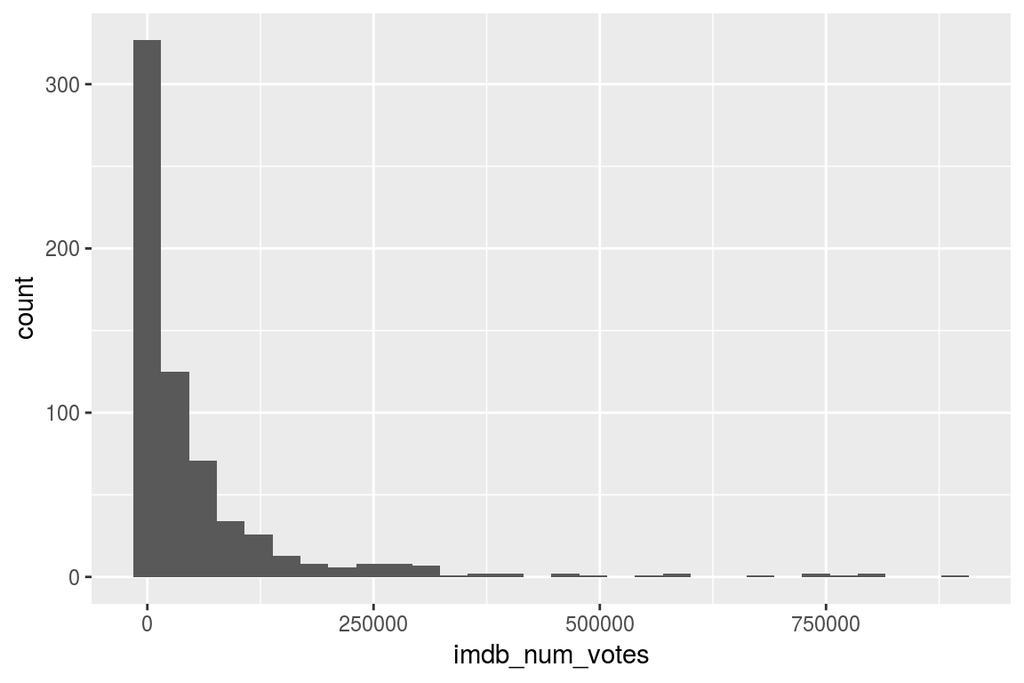

```r
ggplot(movies, aes(x = imdb_num_votes)) +
  geom_histogram(bandwidth = 5)
```

EDA, each step of backward elimination with Adjusted R-squared:

```r
mv_b_03_3 = lm(audience_score ~ genre + mpaa_rating + director, data = movies)
options(max.print = 120)
print(summary(mv_b_03_3), concise=TRUE)
```

```
##
## Call:
## lm(formula = audience_score ~ genre + mpaa_rating + director,
##     data = movies)
##
## Residuals:
##    Min     1Q Median     3Q    Max
## -35.94   0.00   0.00   0.00  32.53
##
## Coefficients: (1 not defined because of singularities)
##                                      Estimate Std. Error t value Pr(>|t|)
## (Intercept)                          37.41333   19.34760   1.934 0.055889
## genreAnimation                       -8.73358   17.35931  -0.503 0.615964
## genreArt House & International        2.06780   14.64326   0.141 0.887979
## genreComedy                          12.66831    8.19526   1.546 0.125218
## genreDocumentary                     16.62271   17.99744   0.924 0.357846
## genreDrama                           15.56398    6.50500   2.393 0.018541
## genreHorror                           5.98642   15.02867   0.398 0.691209
## genreMusical & Performing Arts        8.15925   14.83938   0.550 0.583621
## genreMystery & Suspense              12.06970    8.36525   1.443 0.152100
## genreOther                           -0.57131   11.45768  -0.050 0.960329
## genreScience Fiction & Fantasy        2.81684   18.48133   0.152 0.879157
## mpaa_ratingNC-17                     18.02269   26.39903   0.683 0.496327
## mpaa_ratingPG                       -17.17143   15.25784  -1.125 0.263028
## mpaa_ratingPG-13                    -23.85638   15.52528  -1.537 0.127454
## mpaa_ratingR                        -15.63859   15.44243  -1.013 0.313575
## mpaa_ratingUnrated                    1.88791   23.28248   0.081 0.935530
## directorAbel Ferrara                 30.66129   21.53077   1.424 0.157449
## directorAdam McKay                   25.77474   21.44646   1.202 0.232190
## directorAdam Salky                   -3.33871   21.53077  -0.155 0.877072
## directorAdam Shankman                56.59884   25.81880   2.192 0.030620
## directorAdam Simon                   -3.76115   25.48347  -0.148 0.882953
## directorAdrian Grenier               38.07605   27.35772   1.392 0.166986
## directorAgnes Varda                  30.07605   27.35772   1.099 0.274173
## directorAgnieszka Holland            32.09008   21.12584   1.519 0.131827
##
## (Intercept)                         .
## genreAnimation
## genreArt House & International
## genreComedy
```

[output cut: 13 more lines]

```
## directorAdam McKay
## directorAdam Salky
## directorAdam Shankman               *
## directorAdam Simon
## directorAdrian Grenier
## directorAgnes Varda
## directorAgnieszka Holland
##  [ reached getOption("max.print") -- omitted 523 rows ]
## ---
## Signif. codes:  0 '***' 0.001 '**' 0.01 '*' 0.05 '.' 0.1 ' ' 1
##
## Residual standard error: 17.14 on 103 degrees of freedom
##   (2 observations deleted due to missingness)
## Multiple R-squared:  0.886,  Adjusted R-squared:  0.2829
## F-statistic: 1.469 on 545 and 103 DF,  p-value: 0.008542
```

```r
mv_b_02 = lm(audience_score ~ mpaa_rating + director, data = movies)
options(max.print = 120)
print(summary(mv_b_02), concise=TRUE)
```

```
##
## Call:
## lm(formula = audience_score ~ mpaa_rating + director, data = movies)
##
## Residuals:
##    Min     1Q Median     3Q    Max
##    -35      0      0      0     35
##
## Coefficients: (1 not defined because of singularities)
##                                     Estimate Std. Error t value Pr(>|t|)
## (Intercept)                          42.6807    18.5800   2.297 0.023453
## mpaa_ratingNC-17                     28.3193    25.2728   1.121 0.264857
## mpaa_ratingPG                       -16.6387    14.3835  -1.157 0.249800
## mpaa_ratingPG-13                    -22.8677    14.2517  -1.605 0.111383
## mpaa_ratingR                        -14.4936    14.2032  -1.020 0.309696
## mpaa_ratingUnrated                    0.1064    19.4378   0.005 0.995642
## directorAbel Ferrara                 39.8129    21.0759   1.889 0.061452
## directorAdam McKay                   32.1871    21.0759   1.527 0.129507
## directorAdam Salky                    5.8129    21.0759   0.276 0.783199
## directorAdam Shankman                58.9580    21.5753   2.733 0.007293
## directorAdam Simon                   -4.1871    21.0759  -0.199 0.842881
## directorAdrian Grenier               51.2129    24.9057   2.056 0.042060
## directorAgnes Varda                  43.2129    24.9057   1.735 0.085456
## directorAgnieszka Holland            35.0661    18.5546   1.890 0.061335
## directorAlan Alda                     6.5725    17.3285   0.379 0.705184
## directorAlejandro Agresti            46.9580    21.5753   2.176 0.031601
## directorAlejandro Gonzalez Inarritu  57.8129    21.0759   2.743 0.007080
## directorAlejandro Jodorowsky         58.8129    21.0759   2.791 0.006179
## directorAlex Chandon                  0.8129    21.0759   0.039 0.969300
## directorAlex Gregory                 12.8129    21.0759   0.608 0.544447
## directorAlex Smith                   15.8129    21.0759   0.750 0.454644
## directorAlexandre Aja                15.8129    21.0759   0.750 0.454644
## directorAlice Wu                     59.8129    21.0759   2.838 0.005384
## directorAllan Arkush                 48.9580    21.5753   2.269 0.025156
##
## (Intercept)                         *
## mpaa_ratingNC-17
## mpaa_ratingPG
## mpaa_ratingPG-13
## mpaa_ratingR
```

[output cut: 12 more lines]

```
## directorAlejandro Jodorowsky        **
## directorAlex Chandon
## directorAlex Gregory
## directorAlex Smith
## directorAlexandre Aja
## directorAlice Wu                    **
## directorAllan Arkush                *
##  [ reached getOption("max.print") -- omitted 513 rows ]
## ---
## Signif. codes:  0 '***' 0.001 '**' 0.01 '*' 0.05 '.' 0.1 ' ' 1
##
## Residual standard error: 17.13 on 113 degrees of freedom
##   (2 observations deleted due to missingness)
## Multiple R-squared:  0.8751, Adjusted R-squared:  0.2837
## F-statistic:  1.48 on 535 and 113 DF,  p-value: 0.005724
```

```r
mv_b_03_2 = lm(audience_score ~ title_type + mpaa_rating + director, data = movies)
options(max.print = 120)
print(summary(mv_b_03_2), concise=TRUE)
```

```
##
## Call:
## lm(formula = audience_score ~ title_type + mpaa_rating + director,
##     data = movies)
##
## Residuals:
##    Min     1Q Median     3Q    Max
## -31.80   0.00   0.00   0.00  31.39
##
## Coefficients: (1 not defined because of singularities)
##                                      Estimate Std. Error t value Pr(>|t|)
## (Intercept)                          46.89660   24.19891   1.938 0.055168
## title_typeFeature Film               -4.21925   16.14685  -0.261 0.794342
## title_typeTV Movie                  -74.21925   28.52727  -2.602 0.010541
## mpaa_ratingNC-17                     28.32265   24.53198   1.155 0.250767
## mpaa_ratingPG                       -16.64529   13.96195  -1.192 0.235730
## mpaa_ratingPG-13                    -22.82656   13.83490  -1.650 0.101785
## mpaa_ratingR                        -14.52815   13.78747  -1.054 0.294299
## mpaa_ratingUnrated                   -1.61585   19.98608  -0.081 0.935708
## directorAbel Ferrara                 39.85080   20.45867   1.948 0.053956
## directorAdam McKay                   32.14920   20.45867   1.571 0.118931
## directorAdam Salky                    5.85080   20.45867   0.286 0.775426
## directorAdam Shankman                58.96794   20.94293   2.816 0.005762
## directorAdam Simon                   -4.14920   20.45867  -0.203 0.839656
## directorAdrian Grenier               48.71925   25.99103   1.874 0.063496
## directorAgnes Varda                  40.71925   25.99103   1.567 0.120039
## directorAgnieszka Holland            35.08672   18.01092   1.948 0.053930
## directorAlan Alda                     6.55857   16.82068   0.390 0.697349
## directorAlejandro Agresti            46.96794   20.94293   2.243 0.026905
## directorAlejandro Gonzalez Inarritu  57.85080   20.45867   2.828 0.005564
## directorAlejandro Jodorowsky         58.85080   20.45867   2.877 0.004822
## directorAlex Chandon                  0.85080   20.45867   0.042 0.966903
## directorAlex Gregory                 12.85080   20.45867   0.628 0.531206
## directorAlex Smith                   15.85080   20.45867   0.775 0.440122
## directorAlexandre Aja                15.85080   20.45867   0.775 0.440122
##
## (Intercept)                         .
## title_typeFeature Film
## title_typeTV Movie                  *
## mpaa_ratingNC-17
```

[output cut: 13 more lines]

```
## directorAlejandro Agresti           *
## directorAlejandro Gonzalez Inarritu **
## directorAlejandro Jodorowsky        **
## directorAlex Chandon
## directorAlex Gregory
## directorAlex Smith
## directorAlexandre Aja
##  [ reached getOption("max.print") -- omitted 515 rows ]
## ---
## Signif. codes:  0 '***' 0.001 '**' 0.01 '*' 0.05 '.' 0.1 ' ' 1
##
## Residual standard error: 16.63 on 111 degrees of freedom
##   (2 observations deleted due to missingness)
## Multiple R-squared:  0.8844, Adjusted R-squared:  0.3251
## F-statistic: 1.581 on 537 and 111 DF,  p-value: 0.001765
```

```r
mv_b_03 = lm(audience_score ~ title_type + genre + director, data = movies)
options(max.print = 120)
print(summary(mv_b_03), concise=TRUE)
```

```
##
## Call:
## lm(formula = audience_score ~ title_type + genre + director,
##     data = movies)
##
## Residuals:
##    Min     1Q Median     3Q    Max
## -31.55   0.00   0.00   0.00  32.75
##
## Coefficients: (1 not defined because of singularities)
##                                      Estimate Std. Error t value Pr(>|t|)
## (Intercept)                           75.3911    22.3041   3.380 0.001015
## title_typeFeature Film               -54.3181    24.8977  -2.182 0.031344
## title_typeTV Movie                  -126.1598    36.0423  -3.500 0.000681
## genreAnimation                        -9.5000    16.8814  -0.563 0.574794
## genreArt House & International         1.8853    12.8478   0.147 0.883615
## genreComedy                            5.8540     7.8465   0.746 0.457277
## genreDocumentary                     -27.8640    30.3535  -0.918 0.360711
## genreDrama                            14.1804     6.3352   2.238 0.027287
## genreHorror                            6.4278    14.7160   0.437 0.663149
## genreMusical & Performing Arts         5.6089    14.5771   0.385 0.701176
## genreMystery & Suspense               12.2753     8.1722   1.502 0.136050
## genreOther                             7.6957    11.8428   0.650 0.517217
## genreScience Fiction & Fantasy         2.2278    18.1811   0.123 0.902706
## directorAbel Ferrara                  32.7466    21.1514   1.548 0.124554
## directorAdam McKay                    25.0730    21.0443   1.191 0.236144
## directorAdam Salky                    -1.2534    21.1514  -0.059 0.952858
## directorAdam Shankman                 58.3181    24.8977   2.342 0.021033
## directorAdam Simon                    -3.5008    24.9814  -0.140 0.888817
## directorAdrian Grenier                46.4729    25.7293   1.806 0.073721
## directorAgnes Varda                   38.4729    25.7293   1.495 0.137809
## directorAgnieszka Holland             41.3941    18.3183   2.260 0.025884
## directorAlan Alda                     -1.5902    17.1760  -0.093 0.926410
## directorAlejandro Agresti             37.7466    21.1514   1.785 0.077188
## directorAlejandro Gonzalez Inarritu   50.7466    21.1514   2.399 0.018176
##
## (Intercept)                         **
## title_typeFeature Film              *
## title_typeTV Movie                  ***
## genreAnimation
```

[output cut: 13 more lines]

```
## directorAdam Simon
## directorAdrian Grenier              .
## directorAgnes Varda
## directorAgnieszka Holland           *
## directorAlan Alda
## directorAlejandro Agresti           .
## directorAlejandro Gonzalez Inarritu *
##  [ reached getOption("max.print") -- omitted 520 rows ]
## ---
## Signif. codes:  0 '***' 0.001 '**' 0.01 '*' 0.05 '.' 0.1 ' ' 1
##
## Residual standard error: 16.88 on 106 degrees of freedom
##   (2 observations deleted due to missingness)
## Multiple R-squared:  0.8862, Adjusted R-squared:  0.3045
## F-statistic: 1.523 on 542 and 106 DF,  p-value: 0.004204
```

```r
mv_b_04_2 = lm(audience_score ~ title_type + genre + mpaa_rating + director, data = movies)
options(max.print = 120)
print(summary(mv_b_04_2), concise=TRUE)
```

```
##
## Call:
## lm(formula = audience_score ~ title_type + genre + mpaa_rating +
##     director, data = movies)
##
## Residuals:
##    Min     1Q Median     3Q    Max
## -35.87   0.00   0.00   0.00  33.38
##
## Coefficients: (2 not defined because of singularities)
##                                       Estimate Std. Error t value Pr(>|t|)
## (Intercept)                           89.26245   26.36109   3.386 0.001008
## title_typeFeature Film               -51.41888   25.08189  -2.050 0.042926
## title_typeTV Movie                  -121.49949   35.92435  -3.382 0.001021
## genreAnimation                        -8.77482   16.86125  -0.520 0.603903
## genreArt House & International         1.73170   14.22367   0.122 0.903338
## genreComedy                            9.83137    8.03028   1.224 0.223664
## genreDocumentary                     -34.94523   31.37366  -1.114 0.267966
## genreDrama                            15.39590    6.31867   2.437 0.016560
## genreHorror                            5.79673   14.59765   0.397 0.692123
## genreMusical & Performing Arts         7.93567   14.41386   0.551 0.583140
## genreMystery & Suspense               11.84647    8.12566   1.458 0.147938
## genreOther                             9.91198   11.79706   0.840 0.402757
## genreScience Fiction & Fantasy         2.62118   17.95122   0.146 0.884196
## mpaa_ratingNC-17                      17.76054   25.64179   0.693 0.490109
## mpaa_ratingPG                        -16.19811   14.82453  -1.093 0.277119
## mpaa_ratingPG-13                     -22.77074   15.08528  -1.509 0.134271
## mpaa_ratingR                         -14.74775   15.00305  -0.983 0.327942
## mpaa_ratingUnrated                     2.81051   22.61710   0.124 0.901350
## directorAbel Ferrara                  29.50829   20.91745   1.411 0.161375
## directorAdam McKay                    27.09581   20.83696   1.300 0.196404
## directorAdam Salky                    -4.49171   20.91745  -0.215 0.830403
## directorAdam Shankman                 55.41888   25.08189   2.210 0.029375
## directorAdam Simon                    -4.89254   24.75591  -0.198 0.843727
## directorAdrian Grenier                36.87226   26.57659   1.387 0.168345
##
## (Intercept)                         **
## title_typeFeature Film              *
## title_typeTV Movie                  **
## genreAnimation
```

[output cut: 13 more lines]

```
## mpaa_ratingUnrated
## directorAbel Ferrara
## directorAdam McKay
## directorAdam Salky
## directorAdam Shankman               *
## directorAdam Simon
## directorAdrian Grenier
##  [ reached getOption("max.print") -- omitted 525 rows ]
## ---
## Signif. codes:  0 '***' 0.001 '**' 0.01 '*' 0.05 '.' 0.1 ' ' 1
##
## Residual standard error: 16.65 on 102 degrees of freedom
##   (2 observations deleted due to missingness)
## Multiple R-squared:  0.8935, Adjusted R-squared:  0.3235
## F-statistic: 1.567 on 546 and 102 DF,  p-value: 0.002895
```

```r
mv_b_04 = lm(audience_score ~ title_type + genre + runtime + director, data = movies)
options(max.print = 120)
print(summary(mv_b_04), concise=TRUE)
```

```
##
## Call:
## lm(formula = audience_score ~ title_type + genre + runtime +
##     director, data = movies)
##
## Residuals:
##    Min     1Q Median     3Q    Max
## -30.23   0.00   0.00   0.00  31.88
##
## Coefficients: (1 not defined because of singularities)
##                                       Estimate Std. Error t value Pr(>|t|)
## (Intercept)                           58.47428   25.37198   2.305 0.023152
## title_typeFeature Film               -48.88631   25.10338  -1.947 0.054157
## title_typeTV Movie                  -121.16125   36.07248  -3.359 0.001092
## genreAnimation                        -9.92854   16.81291  -0.591 0.556104
## genreArt House & International         1.38850   12.79857   0.108 0.913815
## genreComedy                            4.11153    7.91481   0.519 0.604525
## genreDocumentary                     -28.57078   30.22947  -0.945 0.346762
## genreDrama                            12.47045    6.42906   1.940 0.055099
## genreHorror                            7.84549   14.68975   0.534 0.594416
## genreMusical & Performing Arts         7.81247   14.60313   0.535 0.593791
## genreMystery & Suspense               10.56382    8.23172   1.283 0.202209
## genreOther                             5.52938   11.89692   0.465 0.643055
## genreScience Fiction & Fantasy        -1.55414   18.31074  -0.085 0.932522
## runtime                                0.14285    0.10358   1.379 0.170784
## directorAbel Ferrara                  31.79972   21.07315   1.509 0.134298
## directorAdam McKay                    21.30171   21.13304   1.008 0.315781
## directorAdam Salky                    -1.20035   21.06199  -0.057 0.954660
## directorAdam Shankman                 50.88645   25.37134   2.006 0.047464
## directorAdam Simon                    -5.28976   24.90961  -0.212 0.832239
## directorAdrian Grenier                50.66887   25.80052   1.964 0.052189
## directorAgnes Varda                   44.38304   25.97643   1.709 0.090482
## directorAgnieszka Holland             38.84077   18.33453   2.118 0.036496
## directorAlan Alda                     -3.37790   17.15245  -0.197 0.844260
## directorAlejandro Agresti             36.79972   21.07315   1.746 0.083686
##
## (Intercept)                         *
## title_typeFeature Film              .
## title_typeTV Movie                  **
## genreAnimation
```

[output cut: 13 more lines]

```
## directorAdam Shankman               *
## directorAdam Simon
## directorAdrian Grenier              .
## directorAgnes Varda                 .
## directorAgnieszka Holland           *
## directorAlan Alda
## directorAlejandro Agresti           .
##  [ reached getOption("max.print") -- omitted 520 rows ]
## ---
## Signif. codes:  0 '***' 0.001 '**' 0.01 '*' 0.05 '.' 0.1 ' ' 1
##
## Residual standard error: 16.81 on 105 degrees of freedom
##   (3 observations deleted due to missingness)
## Multiple R-squared:  0.8882, Adjusted R-squared:  0.3112
## F-statistic: 1.539 on 542 and 105 DF,  p-value: 0.003614
```

```r
mv_b_05_3 = lm(audience_score ~ title_type + genre + runtime + mpaa_rating + director, data = movies)
options(max.print = 120)
print(summary(mv_b_05_3), concise=TRUE)
```

```
##
## Call:
## lm(formula = audience_score ~ title_type + genre + runtime +
##     mpaa_rating + director, data = movies)
##
## Residuals:
##    Min     1Q Median     3Q    Max
## -34.93   0.00   0.00   0.00  33.40
##
## Coefficients: (2 not defined because of singularities)
##                                       Estimate Std. Error t value Pr(>|t|)
## (Intercept)                           68.15871   29.01329   2.349 0.020759
## title_typeFeature Film               -44.05680   25.24915  -1.745 0.084047
## title_typeTV Movie                  -114.49979   35.85576  -3.193 0.001876
## genreAnimation                        -9.26641   16.71681  -0.554 0.580587
## genreArt House & International         2.41920   14.10563   0.172 0.864169
## genreComedy                            8.02528    8.03304   0.999 0.320166
## genreDocumentary                     -33.02015   31.12135  -1.061 0.291215
## genreDrama                            13.23088    6.39570   2.069 0.041127
## genreHorror                            7.14642   14.49281   0.493 0.623012
## genreMusical & Performing Arts        10.84488   14.39348   0.753 0.452928
## genreMystery & Suspense                9.39552    8.18680   1.148 0.253827
## genreOther                             7.39931   11.79013   0.628 0.531692
## genreScience Fiction & Fantasy        -2.27014   18.03300  -0.126 0.900071
## runtime                                0.17816    0.10643   1.674 0.097224
## mpaa_ratingNC-17                      18.87980   25.42700   0.743 0.459502
## mpaa_ratingPG                        -16.35423   14.69556  -1.113 0.268407
## mpaa_ratingPG-13                     -24.23298   14.97923  -1.618 0.108831
## mpaa_ratingR                         -14.81808   14.87230  -0.996 0.321459
## mpaa_ratingUnrated                    -2.60076   22.65173  -0.115 0.908820
## directorAbel Ferrara                  27.84729   20.75879   1.341 0.182776
## directorAdam McKay                    22.90456   20.80647   1.101 0.273584
## directorAdam Salky                    -4.90558   20.73654  -0.237 0.813472
## directorAdam Shankman                 45.56253   25.55084   1.783 0.077556
## directorAdam Simon                    -7.21766   24.57933  -0.294 0.769630
##
## (Intercept)                         *
## title_typeFeature Film              .
## title_typeTV Movie                  **
## genreAnimation
```

[output cut: 13 more lines]

```
## mpaa_ratingR
## mpaa_ratingUnrated
## directorAbel Ferrara
## directorAdam McKay
## directorAdam Salky
## directorAdam Shankman               .
## directorAdam Simon
##  [ reached getOption("max.print") -- omitted 525 rows ]
## ---
## Signif. codes:  0 '***' 0.001 '**' 0.01 '*' 0.05 '.' 0.1 ' ' 1
##
## Residual standard error: 16.5 on 101 degrees of freedom
##   (3 observations deleted due to missingness)
## Multiple R-squared:  0.8963, Adjusted R-squared:  0.336
## F-statistic:   1.6 on 546 and 101 DF,  p-value: 0.002078
```

```r
mv_b_05_2 = lm(audience_score ~ title_type + genre + runtime + mpaa_rating + director, data = movies)
options(max.print = 120)
print(summary(mv_b_05_2), concise=TRUE)
```

```
##
## Call:
## lm(formula = audience_score ~ title_type + genre + runtime +
##     mpaa_rating + director, data = movies)
##
## Residuals:
##    Min     1Q Median     3Q    Max
## -34.93   0.00   0.00   0.00  33.40
##
## Coefficients: (2 not defined because of singularities)
##                                       Estimate Std. Error t value Pr(>|t|)
## (Intercept)                           68.15871   29.01329   2.349 0.020759
## title_typeFeature Film               -44.05680   25.24915  -1.745 0.084047
## title_typeTV Movie                  -114.49979   35.85576  -3.193 0.001876
## genreAnimation                        -9.26641   16.71681  -0.554 0.580587
## genreArt House & International         2.41920   14.10563   0.172 0.864169
## genreComedy                            8.02528    8.03304   0.999 0.320166
## genreDocumentary                     -33.02015   31.12135  -1.061 0.291215
## genreDrama                            13.23088    6.39570   2.069 0.041127
## genreHorror                            7.14642   14.49281   0.493 0.623012
## genreMusical & Performing Arts        10.84488   14.39348   0.753 0.452928
## genreMystery & Suspense                9.39552    8.18680   1.148 0.253827
## genreOther                             7.39931   11.79013   0.628 0.531692
## genreScience Fiction & Fantasy        -2.27014   18.03300  -0.126 0.900071
## runtime                                0.17816    0.10643   1.674 0.097224
## mpaa_ratingNC-17                      18.87980   25.42700   0.743 0.459502
## mpaa_ratingPG                        -16.35423   14.69556  -1.113 0.268407
## mpaa_ratingPG-13                     -24.23298   14.97923  -1.618 0.108831
## mpaa_ratingR                         -14.81808   14.87230  -0.996 0.321459
## mpaa_ratingUnrated                    -2.60076   22.65173  -0.115 0.908820
## directorAbel Ferrara                  27.84729   20.75879   1.341 0.182776
## directorAdam McKay                    22.90456   20.80647   1.101 0.273584
## directorAdam Salky                    -4.90558   20.73654  -0.237 0.813472
## directorAdam Shankman                 45.56253   25.55084   1.783 0.077556
## directorAdam Simon                    -7.21766   24.57933  -0.294 0.769630
##
## (Intercept)                         *
## title_typeFeature Film              .
## title_typeTV Movie                  **
## genreAnimation
```

[output cut: 13 more lines]

```
## mpaa_ratingR
## mpaa_ratingUnrated
## directorAbel Ferrara
## directorAdam McKay
## directorAdam Salky
## directorAdam Shankman               .
## directorAdam Simon
##  [ reached getOption("max.print") -- omitted 525 rows ]
## ---
## Signif. codes:  0 '***' 0.001 '**' 0.01 '*' 0.05 '.' 0.1 ' ' 1
##
## Residual standard error: 16.5 on 101 degrees of freedom
##   (3 observations deleted due to missingness)
## Multiple R-squared:  0.8963, Adjusted R-squared:  0.336
## F-statistic:   1.6 on 546 and 101 DF,  p-value: 0.002078
```

```r
mv_b_05 = lm(audience_score ~ title_type + genre + runtime + mpaa_rating + best_pic_nom, data = movies)
options(max.print = 120)
print(summary(mv_b_05), concise=TRUE)
```

```
##
## Call:
## lm(formula = audience_score ~ title_type + genre + runtime +
##     mpaa_rating + best_pic_nom, data = movies)
##
## Residuals:
##     Min      1Q  Median      3Q     Max
## -51.940 -12.831   1.047  12.616  38.801
##
## Coefficients:
##                                 Estimate Std. Error t value Pr(>|t|)
## (Intercept)                     60.82454    8.77735   6.930 1.04e-11 ***
## title_typeFeature Film         -11.48297    6.49600  -1.768 0.077595 .
## title_typeTV Movie             -20.38764   10.22752  -1.993 0.046647 *
## genreAnimation                   3.91124    6.83693   0.572 0.567475
## genreArt House & International   8.93929    5.29007   1.690 0.091556 .
## genreComedy                      0.36971    2.92044   0.127 0.899301
## genreDocumentary                16.13026    6.97469   2.313 0.021061 *
## genreDrama                       9.86635    2.47376   3.988 7.43e-05 ***
## genreHorror                     -7.47383    4.37157  -1.710 0.087824 .
## genreMusical & Performing Arts  20.17920    5.94678   3.393 0.000734 ***
## genreMystery & Suspense          0.58306    3.23566   0.180 0.857054
## genreOther                       9.68009    4.96639   1.949 0.051724 .
## genreScience Fiction & Fantasy  -3.70046    6.24150  -0.593 0.553475
## runtime                          0.14214    0.03947   3.601 0.000341 ***
## mpaa_ratingNC-17                -9.92200   13.27348  -0.748 0.455038
## mpaa_ratingPG                   -9.61863    4.81300  -1.998 0.046095 *
## mpaa_ratingPG-13               -15.31080    4.91618  -3.114 0.001927 **
## mpaa_ratingR                    -9.45234    4.76917  -1.982 0.047917 *
## mpaa_ratingUnrated              -5.66131    5.50860  -1.028 0.304475
## best_pic_nomyes                 19.50843    3.97704   4.905 1.19e-06 ***
## ---
## Signif. codes:  0 '***' 0.001 '**' 0.01 '*' 0.05 '.' 0.1 ' ' 1
##
## Residual standard error: 17.53 on 630 degrees of freedom
##   (1 observation deleted due to missingness)
## Multiple R-squared:  0.2716, Adjusted R-squared:  0.2497
## F-statistic: 12.37 on 19 and 630 DF,  p-value: < 2.2e-16
```

```r
mv_b_06_2 = lm(audience_score ~ title_type + genre + runtime + mpaa_rating + best_pic_nom + director, data = movies)
options(max.print = 120)
print(summary(mv_b_06_2), concise=TRUE)
```

```
##
## Call:
## lm(formula = audience_score ~ title_type + genre + runtime +
##     mpaa_rating + best_pic_nom + director, data = movies)
##
## Residuals:
##    Min     1Q Median     3Q    Max
## -35.88   0.00   0.00   0.00  33.26
##
## Coefficients: (2 not defined because of singularities)
##                                       Estimate Std. Error t value Pr(>|t|)
## (Intercept)                           78.66289   27.70453   2.839 0.005476
## title_typeFeature Film               -44.27016   23.96662  -1.847 0.067681
## title_typeTV Movie                  -109.84992   34.06059  -3.225 0.001702
## genreAnimation                        -7.63463   15.87456  -0.481 0.631613
## genreArt House & International        -2.80790   13.47315  -0.208 0.835335
## genreComedy                            5.15201    7.66958   0.672 0.503295
## genreDocumentary                     -33.09037   29.54045  -1.120 0.265324
## genreDrama                            11.05338    6.10300   1.811 0.073122
## genreHorror                            3.78459   13.79050   0.274 0.784317
## genreMusical & Performing Arts        13.66875   13.68641   0.999 0.320346
## genreMystery & Suspense                9.41617    7.77092   1.212 0.228476
## genreOther                             0.52026   11.36460   0.046 0.963578
## genreScience Fiction & Fantasy        -1.27637   17.11934  -0.075 0.940716
## runtime                                0.03525    0.10906   0.323 0.747190
## mpaa_ratingNC-17                      22.62804   24.15940   0.937 0.351213
## mpaa_ratingPG                        -14.96252   13.95479  -1.072 0.286205
## mpaa_ratingPG-13                     -21.01566   14.24837  -1.475 0.143367
## mpaa_ratingR                         -11.02026   14.15897  -0.778 0.438216
## mpaa_ratingUnrated                     6.22502   21.65025   0.288 0.774304
## best_pic_nomyes                       27.13857    7.80189   3.478 0.000748
## directorAbel Ferrara                  30.08429   19.71477   1.526 0.130172
## directorAdam McKay                    29.27603   19.83429   1.476 0.143078
## directorAdam Salky                    -3.66895   19.68637  -0.186 0.852532
## directorAdam Shankman                 47.77665   24.26125   1.969 0.051691
##
## (Intercept)                         **
## title_typeFeature Film              .
## title_typeTV Movie                  **
## genreAnimation
```

[output cut: 13 more lines]

```
## mpaa_ratingR
## mpaa_ratingUnrated
## best_pic_nomyes                     ***
## directorAbel Ferrara
## directorAdam McKay
## directorAdam Salky
## directorAdam Shankman               .
##  [ reached getOption("max.print") -- omitted 526 rows ]
## ---
## Signif. codes:  0 '***' 0.001 '**' 0.01 '*' 0.05 '.' 0.1 ' ' 1
##
## Residual standard error: 15.67 on 100 degrees of freedom
##   (3 observations deleted due to missingness)
## Multiple R-squared:  0.9075, Adjusted R-squared:  0.4018
## F-statistic: 1.794 on 547 and 100 DF,  p-value: 0.0002228
```

```r
mv_b_06 = lm(audience_score ~ title_type + genre + runtime + mpaa_rating + best_pic_nom + best_pic_win, data = movies)
options(max.print = 120)
print(summary(mv_b_06), concise=TRUE)
```

```
##
## Call:
## lm(formula = audience_score ~ title_type + genre + runtime +
##     mpaa_rating + best_pic_nom + best_pic_win, data = movies)
##
## Residuals:
##    Min     1Q Median     3Q    Max
## -51.93 -12.83   1.05  12.63  38.81
##
## Coefficients:
##                                 Estimate Std. Error t value Pr(>|t|)
## (Intercept)                     60.92641    8.79333   6.929 1.05e-11 ***
## title_typeFeature Film         -11.48817    6.50087  -1.767 0.077684 .
## title_typeTV Movie             -20.41181   10.23560  -1.994 0.046562 *
## genreAnimation                   3.90497    6.84207   0.571 0.568387
## genreArt House & International   8.93718    5.29401   1.688 0.091875 .
## genreComedy                      0.34299    2.92457   0.117 0.906677
## genreDocumentary                16.11731    6.98008   2.309 0.021264 *
## genreDrama                       9.86878    2.47562   3.986 7.50e-05 ***
## genreHorror                     -7.48358    4.37500  -1.711 0.087660 .
## genreMusical & Performing Arts  20.18940    5.95135   3.392 0.000736 ***
## genreMystery & Suspense          0.57318    3.23831   0.177 0.859566
## genreOther                       9.75435    4.97895   1.959 0.050541 .
## genreScience Fiction & Fantasy  -3.69969    6.24615  -0.592 0.553852
## runtime                          0.14111    0.03971   3.553 0.000409 ***
## mpaa_ratingNC-17                -9.91785   13.28338  -0.747 0.455562
## mpaa_ratingPG                   -9.61965    4.81659  -1.997 0.046235 *
## mpaa_ratingPG-13               -15.28051    4.92133  -3.105 0.001989 **
## mpaa_ratingR                    -9.44375    4.77285  -1.979 0.048292 *
## mpaa_ratingUnrated              -5.64769    5.51297  -1.024 0.306023
## best_pic_nomyes                 19.00958    4.45210   4.270 2.26e-05 ***
## best_pic_winyes                  1.91112    7.64364   0.250 0.802648
## ---
## Signif. codes:  0 '***' 0.001 '**' 0.01 '*' 0.05 '.' 0.1 ' ' 1
##
## Residual standard error: 17.54 on 629 degrees of freedom
##   (1 observation deleted due to missingness)
## Multiple R-squared:  0.2717, Adjusted R-squared:  0.2486
## F-statistic: 11.73 on 20 and 629 DF,  p-value: < 2.2e-16
```

```r
mv_b_07 = lm(audience_score ~ title_type + genre + runtime + mpaa_rating + best_pic_nom + best_pic_win + director, data = movies)
options(max.print = 120)
print(summary(mv_b_07), concise=TRUE)
```

```
##
## Call:
## lm(formula = audience_score ~ title_type + genre + runtime +
##     mpaa_rating + best_pic_nom + best_pic_win + director, data = movies)
##
## Residuals:
##    Min     1Q Median     3Q    Max
## -35.85   0.00   0.00   0.00  33.37
##
## Coefficients: (2 not defined because of singularities)
##                                       Estimate Std. Error t value Pr(>|t|)
## (Intercept)                           79.23818   27.81624   2.849 0.005341
## title_typeFeature Film               -44.68912   24.05868  -1.858 0.066212
## title_typeTV Movie                  -109.44057   34.18310  -3.202 0.001838
## genreAnimation                        -7.83074   15.93185  -0.492 0.624151
## genreArt House & International        -2.65311   13.52136  -0.196 0.844843
## genreComedy                            5.25123    7.69744   0.682 0.496703
## genreDocumentary                     -33.54445   29.65082  -1.131 0.260655
## genreDrama                            11.02508    6.12381   1.800 0.074849
## genreHorror                            3.57149   13.84208   0.258 0.796930
## genreMusical & Performing Arts        12.86910   13.80344   0.932 0.353444
## genreMystery & Suspense                9.33093    7.79859   1.196 0.234363
## genreOther                            -0.21215   11.47448  -0.018 0.985286
## genreScience Fiction & Fantasy        -1.34117   17.17753  -0.078 0.937925
## runtime                                0.03580    0.10943   0.327 0.744210
## mpaa_ratingNC-17                      22.45405   24.24289   0.926 0.356588
## mpaa_ratingPG                        -14.79519   14.00496  -1.056 0.293345
## mpaa_ratingPG-13                     -21.30177   14.30521  -1.489 0.139642
## mpaa_ratingR                         -11.24183   14.21205  -0.791 0.430831
## mpaa_ratingUnrated                     5.92204   21.72981   0.273 0.785782
## best_pic_nomyes                       31.23397   10.60305   2.946 0.004016
## best_pic_winyes                       -6.70322   11.70524  -0.573 0.568168
## directorAbel Ferrara                  30.12300   19.78147   1.523 0.130999
## directorAdam McKay                    29.24070   19.90137   1.469 0.144927
## directorAdam Salky                    -3.62636   19.75299  -0.184 0.854714
##
## (Intercept)                         **
## title_typeFeature Film              .
## title_typeTV Movie                  **
## genreAnimation
```

[output cut: 13 more lines]

```
## mpaa_ratingR
## mpaa_ratingUnrated
## best_pic_nomyes                     **
## best_pic_winyes
## directorAbel Ferrara
## directorAdam McKay
## directorAdam Salky
##  [ reached getOption("max.print") -- omitted 527 rows ]
## ---
## Signif. codes:  0 '***' 0.001 '**' 0.01 '*' 0.05 '.' 0.1 ' ' 1
##
## Residual standard error: 15.72 on 99 degrees of freedom
##   (3 observations deleted due to missingness)
## Multiple R-squared:  0.9078, Adjusted R-squared:  0.3977
## F-statistic:  1.78 on 548 and 99 DF,  p-value: 0.000281
```

End of document.